# Data Challenge

## Content:

1. Load File and Exploratory Data Analysis:
2. Data preprocessing ( In another jupyter notebook document)
3. Model 1 ( In another jupyter notebook document)
4. Model 2 ( In another jupyter notebook document)

```python
# Import libraries
import numpy as np
import pandas as pd
import matplotlib.pyplot as plt
import math
import seaborn as sns

import scipy
from functools import reduce
import warnings

warnings.filterwarnings('ignore')
```

```python
print(np.__version__)
print(pd.__version__)
print(sns.__version__)
```

```
1.15.3
0.23.4
0.9.0
```

Load the file

```python
file='D:\Take_Home\data_challenge_dataset.csv'
df= pd.read_csv(file)
shape=df.shape
shape
```

```
(284807, 30)
```

## Data Loaded

```python
df.head(n=10)
```

|  | V1 | V2 | V3 | V4 | V5 | V6 | V7 | V8 | V9 | V10 | ... | V21 | V22 | V23 | V24 | V25 | V26 | V27 | V28 | V29 | Class |
| --- | --- | --- | --- | --- | --- | --- | --- | --- | --- | --- | --- | --- | --- | --- | --- | --- | --- | --- | --- | --- | --- |
| 0 | NaN | -0.072781 | 2.536347 | NaN | -0.338321 | 0.462388 | NaN | 0.098698 | 0.363787 | 0.090794 | ... | -0.018307 | 0.277838 | -0.110474 | 0.066928 | 0.128539 | -0.189115 | NaN | -0.021053 | 149.62 | 0 |
| 1 | 1.191857 | 0.266151 | 0.166480 | 0.448154 | 0.060018 | -0.082361 | -0.078803 | 0.085102 | NaN | -0.166974 | ... | -0.225775 | -0.638672 | NaN | -0.339846 | 0.167170 | 0.125895 | -0.008983 | 0.014724 | 2.69 | 0 |
| 2 | -1.358354 | -1.340163 | 1.773209 | 0.379780 | -0.503198 | 1.800499 | 0.791461 | 0.247676 | -1.514654 | 0.207643 | ... | 0.247998 | 0.771679 | 0.909412 | NaN | -0.327642 | -0.139097 | -0.055353 | -0.059752 | 378.66 | 0 |
| 3 | -0.966272 | -0.185226 | 1.792993 | -0.863291 | -0.010309 | 1.247203 | 0.237609 | 0.377436 | -1.387024 | -0.054952 | ... | -0.108300 | 0.005274 | -0.190321 | -1.175575 | 0.647376 | -0.221929 | 0.062723 | 0.061458 | 123.50 | 0 |
| 4 | -1.158233 | 0.877737 | 1.548718 | 0.403034 | -0.407193 | 0.095921 | NaN | -0.270533 | 0.817739 | 0.753074 | ... | -0.009431 | 0.798278 | -0.137458 | 0.141267 | -0.206010 | 0.502292 | 0.219422 | 0.215153 | 69.99 | 0 |
| 5 | -0.425966 | 0.960523 | 1.141109 | -0.168252 | 0.420987 | -0.029728 | 0.476201 | 0.260314 | -0.568671 | -0.371407 | ... | -0.208254 | -0.559825 | -0.026398 | -0.371427 | -0.232794 | NaN | 0.253844 | 0.081080 | 3.67 | 0 |
| 6 | 1.229658 | 0.141004 | 0.045371 | 1.202613 | 0.191881 | 0.272708 | -0.005159 | 0.081213 | 0.464960 | -0.099254 | ... | -0.167716 | -0.270710 | -0.154104 | -0.780055 | 0.750137 | -0.257237 | 0.034507 | 0.005168 | 4.99 | 0 |
| 7 | -0.644269 | 1.417964 | 1.074380 | -0.492199 | 0.948934 | 0.428118 | 1.120631 | -3.807864 | 0.615375 | 1.249376 | ... | 1.943465 | -1.015455 | 0.057504 | -0.649709 | -0.415267 | -0.051634 | -1.206921 | -1.085339 | 40.80 | 0 |
| 8 | -0.894286 | 0.286157 | -0.113192 | -0.271526 | 2.669599 | NaN | 0.370145 | NaN | -0.392048 | -0.410430 | ... | -0.073425 | -0.268092 | -0.204233 | 1.011592 | NaN | NaN | 0.011747 | 0.142404 | 93.20 | 0 |
| 9 | -0.338262 | 1.119593 | 1.044367 | -0.222187 | 0.499361 | -0.246761 | 0.651583 | 0.069539 | -0.736727 | -0.366846 | ... | -0.246914 | NaN | -0.120794 | -0.385050 | -0.069733 | NaN | 0.246219 | 0.083076 | 3.68 | 0 |

10 rows × 30 columns

```python
features=df.columns
features
```

```
Index(['V1', 'V2', 'V3', 'V4', 'V5', 'V6', 'V7', 'V8', 'V9', 'V10', 'V11',
       'V12', 'V13', 'V14', 'V15', 'V16', 'V17', 'V18', 'V19', 'V20', 'V21',
       'V22', 'V23', 'V24', 'V25', 'V26', 'V27', 'V28', 'V29', 'Class'],
      dtype='object')
```

### Exploratory Data Analysis

Calculate the class frequency and number of class

```python
100*df.groupby('Class').size()/len(df)
```

```
Class
0    99.827251
1     0.172749
dtype: float64
```

Class 0 has more than 99.8% datapoint and class 1 has only .17%. Therefore dataset is imbalanced and I need to figureout a way to deal with this issue. I can think of over sampling from class 1 and under sampling of class 0. I will discuss it more in data preprocessing.

In the next step, missing values were identified in this data

```python
100*df.isnull().sum() / len(df)
```

```
V1       9.999754
V2       9.999754
V3       9.999754
V4       9.999754
V5       9.999754
V6       9.999754
V7       9.999754
V8       9.999754
V9       9.999754
V10      9.999754
V11      9.999754
V12      9.999754
V13      9.999754
V14      9.999754
V15      9.999754
V16      9.999754
V17      9.999754
V18      9.999754
V19      9.999754
V20      9.999754
V21      9.999754
V22      9.999754
V23      9.999754
V24      9.999754
V25      9.999754
V26      9.999754
V27      9.999754
V28      9.999754
V29      9.999754
Class    0.000000
dtype: float64
```

### Each feature has almost 10% of missing data.

```python
100*df[df['Class']==0].isnull().sum() / len(df[df['Class']==0])
```

```
V1       10.000528
V2       10.001583
V3        9.995252
V4        9.999824
V5        9.999121
V6       10.002286
V7       10.001934
V8       10.000176
V9       10.004397
V10      10.000528
V11       9.996659
V12      10.002990
V13       9.998417
V14       9.998066
V15      10.001934
V16      10.001231
V17       9.999472
V18      10.002638
V19       9.998066
V20       9.999824
V21       9.999121
V22       9.998066
V23      10.000528
V24      10.001934
V25       9.999824
V26      10.000176
V27      10.001231
V28      10.001583
V29       9.999121
Class     0.000000
dtype: float64
```

```python
100*df[df['Class']==1].isnull().sum() / len(df[df['Class']==1])
```

```
V1        9.552846
V2        8.943089
V3       12.601626
V4        9.959350
V5       10.365854
V6        8.536585
V7        8.739837
V8        9.756098
V9        7.317073
V10       9.552846
V11      11.788618
V12       8.130081
V13      10.772358
V14      10.975610
V15       8.739837
V16       9.146341
V17      10.162602
V18       8.333333
V19      10.975610
V20       9.959350
V21      10.365854
V22      10.975610
V23       9.552846
V24       8.739837
V25       9.959350
V26       9.756098
V27       9.146341
V28       8.943089
V29      10.365854
Class     0.000000
dtype: float64
```

### Each class has almost 10% of missing data in each feature

```python
# df_0 contains datapoints of class 1 whereas df_0 contains class 0
df_0=df[df['Class']==0]
df_1=df[df['Class']==1]
```

# Exploratory Data Analysis by Visualization

### Calculated the correlation matrix of each class to know about the relation between the features.

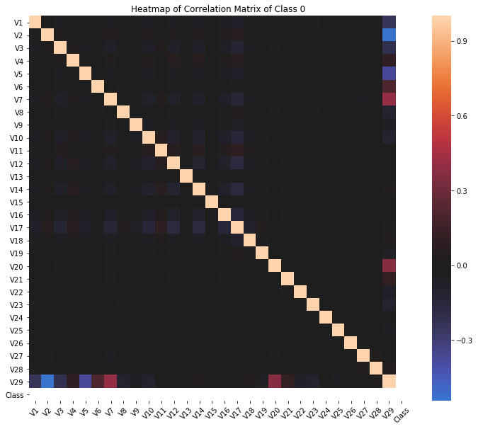

```python
fig = plt.figure(figsize=(12, 10))

sns.heatmap(df_0.corr(), center=0)
plt.xticks(rotation=45)
plt.title('Heatmap of Correlation Matrix of Class 0')
plt.show()
```

# EDA 1:

In class 0, There is no co relation between the features. Feature 29 is correlated to some of the feature namely: V2, V7, V20

### Correlation matrix only tell about linear relationship. The quadratic or higher degree relation between the features is still possible.

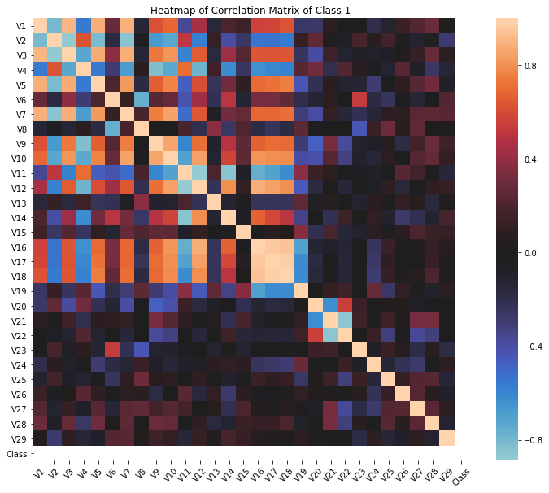

```python
fig = plt.figure(figsize=(12, 10))

sns.heatmap(df_1.corr(), center=0)
plt.xticks(rotation=45)
plt.title('Heatmap of Correlation Matrix of Class 1')
plt.show()
```

## EDA 2:

In class 1, features (V23 to V29, V15, V13 are almost uncorrelated to rest of the features. Almost all the features from V1 to V18 are highily correlated.

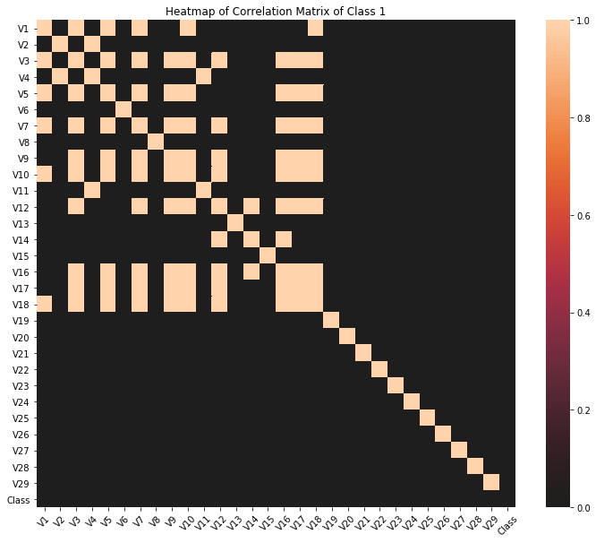

```python
fig = plt.figure(figsize=(12, 10))

sns.heatmap(df_1.corr()> abs(.6), center=0)
plt.xticks(rotation=45)
plt.title('Heatmap of Correlation Matrix of Class 1')
plt.show()
```

## EDA 4 and EDA 5

This shows the Box plot and density curve to see the frequency distribution of Class 0 and Class 1.

### Replaced missing values by 0 to check the overall distribution. Kindly ignore peak at 0.

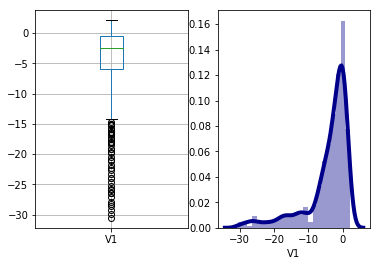

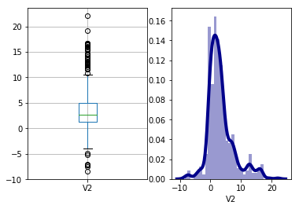

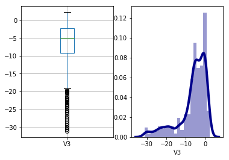

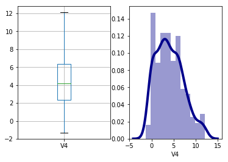

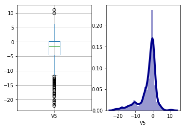

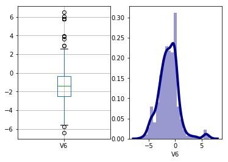

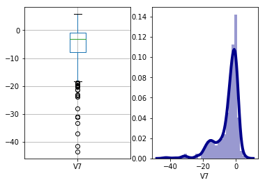

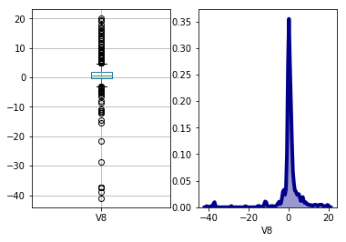

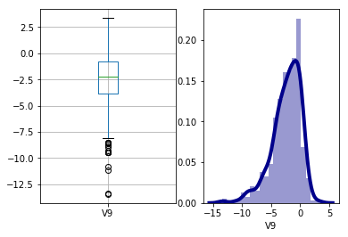

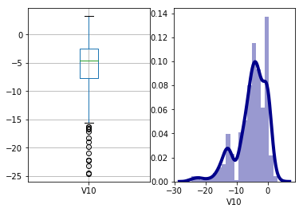

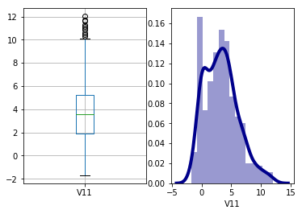

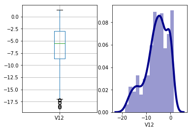

[18 more figures not shown]

```python
for feature in features:

    fig= plt.figure()
    fig.add_subplot(1,2,1),df_1.boxplot(column= feature)
    fig.add_subplot(1,2,2),sns.distplot(df_1[feature].fillna(0) , kde=True,  color = 'darkblue', kde_kws={'linewidth': 4})
```

# EDA 4 : Class1

If I ignore the frequency at 0 and the outliers than almost all the features have Guassian Distribution.

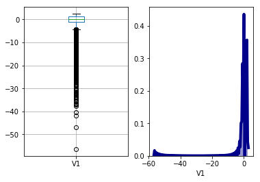

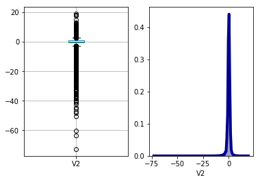

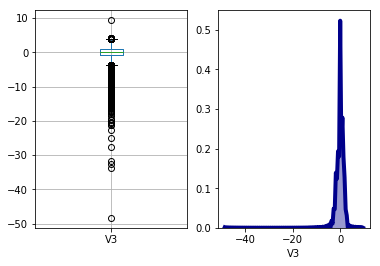

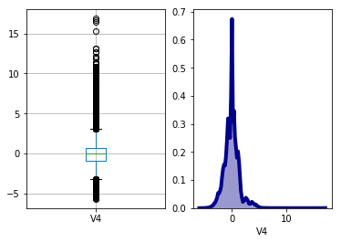

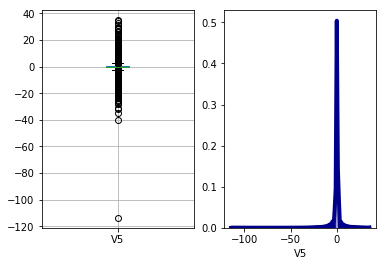

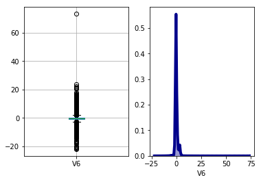

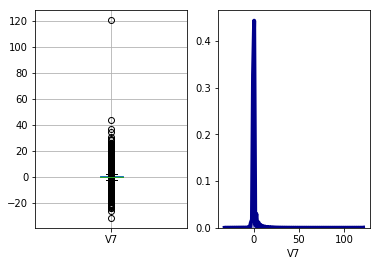

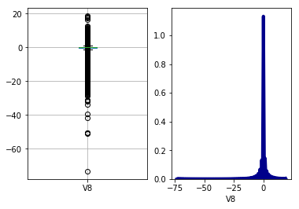

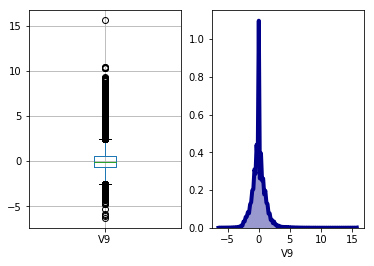

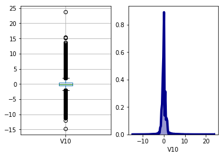

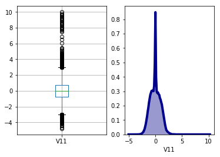

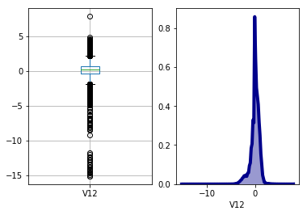

[18 more figures not shown]

```python
for feature in features:

    fig= plt.figure()
    fig.add_subplot(1,2,1),df_0.boxplot(column= feature)
    fig.add_subplot(1,2,2),sns.distplot(df_0[feature].fillna(0) , kde=True,  color = 'darkblue', kde_kws={'linewidth': 4})
```

# EDA 5 : Class 0

If I ignore the frequency at 0 and the outliers than almost all the features have guassian distribution.

##### Now calculated the mean, standard deviation, minimum value, maximum value and quartiles too see the overall behavior of each feature in each class

```python
df_0.describe()
```

|  | V1 | V2 | V3 | V4 | V5 | V6 | V7 | V8 | V9 | V10 | ... | V21 | V22 | V23 | V24 | V25 | V26 | V27 | V28 | V29 | Class |
| --- | --- | --- | --- | --- | --- | --- | --- | --- | --- | --- | --- | --- | --- | --- | --- | --- | --- | --- | --- | --- | --- |
| count | 255882.000000 | 255879.000000 | 255897.000000 | 255884.000000 | 255886.000000 | 255877.000000 | 255878.000000 | 255883.000000 | 255871.000000 | 255882.000000 | ... | 255886.000000 | 255889.000000 | 255882.000000 | 255878.000000 | 255884.000000 | 255883.000000 | 255880.000000 | 255879.000000 | 255886.000000 | 284315.0 |
| mean | 0.006522 | -0.005348 | 0.012725 | -0.007881 | 0.005286 | 0.002641 | 0.008847 | 0.000732 | 0.003518 | 0.008751 | ... | -0.000834 | -0.000544 | 0.000505 | 0.000426 | -0.000195 | -0.000178 | -0.000244 | 0.000041 | 88.401127 | 0.0 |
| std | 1.928963 | 1.636045 | 1.460059 | 1.400721 | 1.357733 | 1.329704 | 1.182432 | 1.154773 | 1.090551 | 1.040734 | ... | 0.716645 | 0.722780 | 0.614802 | 0.605800 | 0.520691 | 0.482614 | 0.394262 | 0.330150 | 248.005040 | 0.0 |
| min | -56.407510 | -72.715728 | -48.325589 | -5.683171 | -113.743307 | -21.929312 | -31.764946 | -73.216718 | -6.290730 | -14.741096 | ... | -34.830382 | -10.933144 | -44.807735 | -2.836627 | -10.295397 | -2.604551 | -22.565679 | -15.430084 | 0.000000 | 0.0 |
| 25% | -0.918005 | -0.598970 | -0.883227 | -0.849768 | -0.690841 | -0.766823 | -0.551000 | -0.208516 | -0.641460 | -0.533627 | ... | -0.228625 | -0.542957 | -0.161562 | -0.354389 | -0.317151 | -0.327327 | -0.070894 | -0.052931 | 5.682500 | 0.0 |
| 50% | 0.017825 | 0.063727 | 0.182090 | -0.021578 | -0.054968 | -0.272910 | 0.040869 | 0.022355 | -0.051405 | -0.091283 | ... | -0.029993 | 0.006514 | -0.010959 | 0.041541 | 0.015779 | -0.052422 | 0.001187 | 0.011145 | 22.000000 | 0.0 |
| 75% | 1.315867 | 0.801111 | 1.029542 | 0.737161 | 0.612127 | 0.400007 | 0.570298 | 0.326813 | 0.596985 | 0.454813 | ... | 0.185335 | 0.527348 | 0.147601 | 0.439879 | 0.350229 | 0.240468 | 0.090492 | 0.077863 | 77.000000 | 0.0 |
| max | 2.454930 | 18.902453 | 9.382558 | 16.875344 | 34.801666 | 73.301626 | 120.589494 | 18.709255 | 15.594995 | 23.745136 | ... | 22.614889 | 8.272233 | 22.528412 | 4.584549 | 7.519589 | 3.517346 | 12.152401 | 33.847808 | 19656.530000 | 0.0 |

8 rows × 30 columns

```python
df.describe()
```

|  | V1 | V2 | V3 | V4 | V5 | V6 | V7 | V8 | V9 | V10 | ... | V21 | V22 | V23 | V24 | V25 | V26 | V27 | V28 | V29 | Class |
| --- | --- | --- | --- | --- | --- | --- | --- | --- | --- | --- | --- | --- | --- | --- | --- | --- | --- | --- | --- | --- | --- |
| count | 256327.000000 | 256327.000000 | 256327.000000 | 256327.000000 | 256327.000000 | 256327.000000 | 256327.000000 | 256327.000000 | 256327.000000 | 256327.000000 | ... | 256327.000000 | 256327.000000 | 256327.000000 | 256327.000000 | 256327.000000 | 256327.000000 | 256327.000000 | 256327.000000 | 256327.000000 | 284807.000000 |
| mean | -0.001855 | 0.001016 | 0.000476 | 0.000029 | 0.000192 | 0.000221 | -0.000832 | 0.001599 | -0.001070 | -0.001081 | ... | 0.000373 | -0.000521 | 0.000435 | 0.000242 | -0.000116 | -0.000088 | 0.000086 | 0.000153 | 88.463396 | 0.001727 |
| std | 1.957926 | 1.651584 | 1.519391 | 1.417511 | 1.378669 | 1.332159 | 1.241105 | 1.187431 | 1.099997 | 1.085192 | ... | 0.733762 | 0.725003 | 0.618081 | 0.605657 | 0.521329 | 0.482607 | 0.397504 | 0.330702 | 248.040629 | 0.041527 |
| min | -56.407510 | -72.715728 | -48.325589 | -5.683171 | -113.743307 | -21.929312 | -43.557242 | -73.216718 | -13.434066 | -24.588262 | ... | -34.830382 | -10.933144 | -44.807735 | -2.836627 | -10.295397 | -2.604551 | -22.565679 | -15.430084 | 0.000000 | 0.000000 |
| 25% | -0.920793 | -0.598073 | -0.888388 | -0.848423 | -0.692812 | -0.768247 | -0.553502 | -0.208516 | -0.644112 | -0.535903 | ... | -0.228512 | -0.542946 | -0.161762 | -0.354556 | -0.317167 | -0.327224 | -0.070878 | -0.052945 | 5.640000 | 0.000000 |
| 50% | 0.015389 | 0.065034 | 0.179871 | -0.018836 | -0.055993 | -0.273935 | 0.039835 | 0.022608 | -0.052607 | -0.092313 | ... | -0.029669 | 0.006540 | -0.011011 | 0.041439 | 0.015954 | -0.052294 | 0.001296 | 0.011181 | 22.000000 | 0.000000 |
| 75% | 1.315404 | 0.804324 | 1.028192 | 0.742473 | 0.611817 | 0.399117 | 0.569714 | 0.327949 | 0.595965 | 0.453653 | ... | 0.186117 | 0.527516 | 0.147746 | 0.439527 | 0.350374 | 0.240773 | 0.090973 | 0.078202 | 77.000000 | 0.000000 |
| max | 2.454930 | 22.057729 | 9.382558 | 16.875344 | 34.801666 | 73.301626 | 120.589494 | 20.007208 | 15.594995 | 23.745136 | ... | 27.202839 | 8.361985 | 22.528412 | 4.584549 | 7.519589 | 3.517346 | 12.152401 | 33.847808 | 19656.530000 | 1.000000 |

8 rows × 30 columns

```python
df_1.describe()
```

|  | V1 | V2 | V3 | V4 | V5 | V6 | V7 | V8 | V9 | V10 | ... | V21 | V22 | V23 | V24 | V25 | V26 | V27 | V28 | V29 | Class |
| --- | --- | --- | --- | --- | --- | --- | --- | --- | --- | --- | --- | --- | --- | --- | --- | --- | --- | --- | --- | --- | --- |
| count | 445.000000 | 448.000000 | 430.000000 | 443.000000 | 441.000000 | 450.000000 | 449.000000 | 444.000000 | 456.000000 | 445.000000 | ... | 441.000000 | 438.000000 | 445.000000 | 449.000000 | 443.000000 | 444.000000 | 447.000000 | 448.000000 | 441.000000 | 492.0 |
| mean | -4.818759 | 3.636083 | -7.289105 | 4.569015 | -2.955735 | -1.376004 | -5.517052 | 0.501029 | -2.575517 | -5.654916 | ... | 0.700323 | 0.012932 | -0.039872 | -0.104461 | 0.045357 | 0.051683 | 0.188877 | 0.064084 | 124.594535 | 1.0 |
| std | 6.739938 | 4.325549 | 7.376186 | 2.906602 | 5.142864 | 1.897524 | 7.225609 | 6.733905 | 2.489102 | 4.853579 | ... | 3.806057 | 1.552813 | 1.646475 | 0.508106 | 0.809089 | 0.475934 | 1.263053 | 0.560922 | 265.744320 | 0.0 |
| min | -30.552380 | -8.402154 | -31.103685 | -1.313275 | -22.105532 | -6.406267 | -43.557242 | -41.044261 | -13.434066 | -24.588262 | ... | -22.797604 | -8.887017 | -19.254328 | -2.028024 | -4.781606 | -1.152671 | -7.263482 | -1.869290 | 0.000000 | 1.0 |
| 25% | -6.003422 | 1.253310 | -9.130223 | 2.367732 | -4.543590 | -2.492665 | -7.934389 | -0.204866 | -3.840191 | -7.731071 | ... | 0.039289 | -0.540559 | -0.339939 | -0.436539 | -0.322672 | -0.261713 | -0.023142 | -0.124530 | 1.000000 | 1.0 |
| 50% | -2.434004 | 2.720177 | -5.195407 | 4.180779 | -1.446749 | -1.424616 | -3.005953 | 0.602649 | -2.208768 | -4.594952 | ... | 0.589669 | 0.041267 | -0.074098 | -0.060327 | 0.096510 | -0.003464 | 0.378105 | 0.139421 | 9.130000 | 1.0 |
| 75% | -0.481531 | 5.022687 | -2.321750 | 6.374645 | 0.249192 | -0.374131 | -0.916696 | 1.732091 | -0.787850 | -2.495619 | ... | 1.226648 | 0.619658 | 0.303550 | 0.284122 | 0.466959 | 0.396733 | 0.821215 | 0.384374 | 105.890000 | 1.0 |
| max | 2.132386 | 22.057729 | 2.250210 | 12.114672 | 11.095089 | 6.474115 | 5.802537 | 20.007208 | 3.353525 | 3.245086 | ... | 27.202839 | 8.361985 | 5.466230 | 1.091435 | 2.208209 | 2.745261 | 3.052358 | 1.779364 | 2125.870000 | 1.0 |

8 rows × 30 columns

#### Calculate the 10% and 90 % quantile of each feature in each class.

```python
Quantile_0=df_0.quantile([.1, .9])
Quantile_1=df_1.quantile([.1, .9])
Quantile_0
```

|  | V1 | V2 | V3 | V4 | V5 | V6 | V7 | V8 | V9 | V10 | ... | V21 | V22 | V23 | V24 | V25 | V26 | V27 | V28 | V29 | Class |
| --- | --- | --- | --- | --- | --- | --- | --- | --- | --- | --- | --- | --- | --- | --- | --- | --- | --- | --- | --- | --- | --- |
| 0.1 | -1.886904 | -1.359368 | -1.795384 | -1.659241 | -1.298149 | -1.164104 | -1.072509 | -0.457995 | -1.288710 | -1.027070 | ... | -0.367331 | -0.867747 | -0.327951 | -0.870174 | -0.605650 | -0.548886 | -0.211223 | -0.155376 | 1.000 | 0.0 |
| 0.9 | 2.015353 | 1.322007 | 1.677619 | 1.472988 | 1.407566 | 1.514177 | 1.039135 | 0.767638 | 1.301217 | 1.119761 | ... | 0.374106 | 0.913196 | 0.339188 | 0.706165 | 0.600594 | 0.689244 | 0.264725 | 0.179223 | 202.675 | 0.0 |

2 rows × 30 columns

```python
Quantile_1
```

|  | V1 | V2 | V3 | V4 | V5 | V6 | V7 | V8 | V9 | V10 | ... | V21 | V22 | V23 | V24 | V25 | V26 | V27 | V28 | V29 | Class |
| --- | --- | --- | --- | --- | --- | --- | --- | --- | --- | --- | --- | --- | --- | --- | --- | --- | --- | --- | --- | --- | --- |
| 0.1 | -15.092662 | -0.155255 | -19.640502 | 1.052419 | -10.564657 | -3.605455 | -15.980675 | -2.441542 | -5.881176 | -12.994273 | ... | -0.812098 | -0.980351 | -0.826113 | -0.760396 | -0.836988 | -0.494772 | -1.332306 | -0.723930 | 0.76 | 1.0 |
| 0.9 | 0.950311 | 9.114437 | -0.490534 | 8.561871 | 1.407133 | 0.656507 | 0.564402 | 5.451824 | 0.082461 | -0.370614 | ... | 2.158143 | 1.131781 | 0.985563 | 0.516808 | 0.917585 | 0.639747 | 1.413804 | 0.665954 | 346.94 | 1.0 |

2 rows × 30 columns

# Inspiration from EDA to deal with missing values:

### Missing values for Class 0:

EDA 1. correlation matrix shows that features are uncorrelated EDA 2. Box plot and Density curve shows that each feature contains outlier. Moreover, missing values were replaced by 0, so ignore the occurance of 0 than the distribution of features is guassian.

#### Steps for filling missing values for each feature:

1. Ignore the tail of the distribution of each feature by picking values between 10% quantile to 90% quantile. Let us call these values to set S.
2. Find the mean and standard deviation of S.
3. Find the gaussian distribution of S and generate random number equal to the missing values.
4. Fill random numbers randomly into the place of missing values.

#### Note that the process define above does not affect the distribution of feature. Moreover, there is no correlation between the features so the above mentioned method would be a better option.

### Missing values for Class 1:

EDA 1. correlation matrix shows that features,'V6','V13','V15','V22','V23','V24','V25','V26','V27','V28','V29' are not correlated with other features.and EDA 2. Box plot and Density curve shows that each feature contains outlier. Moreover, missing values were replaced by 0, so ignore the occurance of 0 than the distribution of features is guassian.

#### Steps for filling missing values for each feature:

##### Dealing with unco-related features:

1. Ignore the tail of the distribution of each feature by picking values between 10% quantile to 90% quantile. Let call these values to set S.
2. Find the mean and standard deviation of S.
3. Find the gaussian distribution of S and generate random number equal to the the missing values.
4. Fill random numbers randomly into the place of missing values.

#### Dealing with co-rrelated features:

V1 is correlated to 'V2','V3','V5','V7','V9','V10','V18' so we can predict these features by the linear regression on the basis of V1.

### Note:

#### fill the missing values

```python
# Dealing with missing values of class 0
feature=['V1','V2','V3','V4','V5','V6','V7','V8','V9','V10','V11','V12','V13','V14','V15'
         ,'V16','V17','V18','V19','V20','V21','V22','V23','V24','V25','V26','V27','V28','V29']
Quantile=df_0.quantile([.1, .9])
import statistics
for f in feature:
    index=df_0.columns.get_loc(f)
    column=[]
    for value in df_0.values[:,index]:
        if value > Quantile[f].values[0] and value < Quantile[f].values[1]:
            column.append(value)
    mean_column= statistics.mean(column)
    stdev_column= statistics.stdev(column)
    m=df_0[f].isnull()
    c=m[m.values==True]

    nan_total=len(c)
    fill_values = np.random.normal(mean_column,stdev_column,nan_total)
    df_0.loc[m, f] = fill_values
```

##### Check the features in each class after dealing with the missing values.

```python
100*df_0.isnull().sum() / len(df_0)
```

```
V1       0.0
V2       0.0
V3       0.0
V4       0.0
V5       0.0
V6       0.0
V7       0.0
V8       0.0
V9       0.0
V10      0.0
V11      0.0
V12      0.0
V13      0.0
V14      0.0
V15      0.0
V16      0.0
V17      0.0
V18      0.0
V19      0.0
V20      0.0
V21      0.0
V22      0.0
V23      0.0
V24      0.0
V25      0.0
V26      0.0
V27      0.0
V28      0.0
V29      0.0
Class    0.0
dtype: float64
```

No missing Value

```python
feature=['V1','V6','V13','V15','V22','V23','V24','V25','V26','V27','V28','V29']
Quantile=df_1.quantile([.1, .9])
import statistics
for f in feature:
    index=df_1.columns.get_loc(f)
    column=[]
    for value in df_1.values[:,index]:
        if value > Quantile[f].values[0] and value < Quantile[f].values[1]:
            column.append(value)
    mean_column= statistics.mean(column)
    stdev_column= statistics.stdev(column)
    m=df_1[f].isnull()
    c=m[m.values==True]

    nan_total=len(c)
    fill_values = np.random.normal(mean_column,stdev_column,nan_total)
    df_1.loc[m, f] = fill_values
```

```python
from sklearn.linear_model import LinearRegression

train_feature=[['V22'],['V1'],['V3'],['V6'],['V18'],['V16'],['V10']]
test_feature=[['V20','V21'],['V2','V3','V5','V7','V9','V10','V18'],['V4'],['V8'],['V16','V17'],['V19'],['V11','V12','V14']]
for i in range(0,len(train_feature)):
    train_f=train_feature[i]
    test_f=test_feature[i]
    for f_tst in test_f:

        df_predict=pd.DataFrame()
        df_predict[train_f[0]]=df_1[train_f[0]]
        df_predict[f_tst]=df_1[f_tst]
        train=df_predict[df_predict[f_tst].notnull()]
        test=df_predict[df_predict[f_tst].isnull()]
        reg = LinearRegression().fit(train.values[:,0].reshape(-1,1), train.values[:,1].reshape(-1,1))
        fill_values=reg.predict(test.values[:,0].reshape(-1,1))
        m=df_1[f_tst].isnull()
        c=m[m.values==True]

        nan_total=len(c)
        df_1.loc[m, f_tst] = fill_values.flatten()
```

```python
100*df_1.isnull().sum() / len(df_1)
```

```
V1       0.0
V2       0.0
V3       0.0
V4       0.0
V5       0.0
V6       0.0
V7       0.0
V8       0.0
V9       0.0
V10      0.0
V11      0.0
V12      0.0
V13      0.0
V14      0.0
V15      0.0
V16      0.0
V17      0.0
V18      0.0
V19      0.0
V20      0.0
V21      0.0
V22      0.0
V23      0.0
V24      0.0
V25      0.0
V26      0.0
V27      0.0
V28      0.0
V29      0.0
Class    0.0
dtype: float64
```

No missing value found

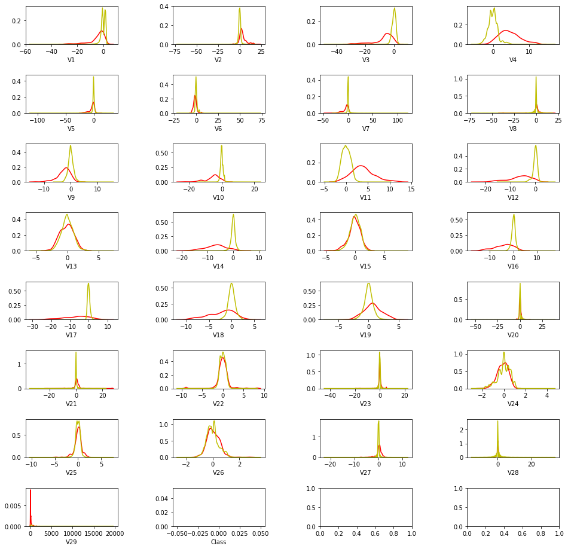

```python
figures, axes = plt.subplots(nrows = math.ceil(len(features)/4),ncols = 4,figsize=(16, 16))
plt.subplots_adjust(hspace=0.8, wspace=0.6)
for feature, axis in zip(features,axes.flatten()):
        sns.distplot(df_1.loc[(df_1['Class'] == 1),feature],
                color='r',
                kde=True,
                hist=False,
                ax=axis)
        sns.distplot(df_0.loc[(df_0['Class'] == 0),feature],
                color='y',
                kde=True,
                hist=False,
                ax=axis)
```

### EDA 6:

Almost all the features in both the class have gaussian distribution

```
[9.93670895e-01 3.85284758e-03 8.50822656e-04 5.94990136e-04]
[9.99533489e-01 6.13127610e-05 3.90679519e-05 3.63747199e-05]
```

```
No handles with labels found to put in legend.
```

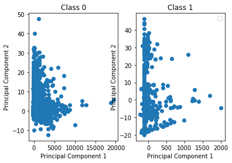

```python
from sklearn import decomposition
pca = decomposition.PCA(n_components=4)
pca.fit(df_1)
X = pca.transform(df_1)
print(pca.explained_variance_ratio_)

pca.fit(df_0)
Y = pca.transform(df_0)
print(pca.explained_variance_ratio_)
plt.subplot(1,2,1),plt.scatter(Y[:, 0], Y[:, 1])
plt.xlabel('Principal Component 1')
plt.ylabel('Principal Component 2')
plt.title('Class 0')
plt.subplot(1,2,2),plt.scatter(X[:, 0], X[:, 1])
plt.xlabel('Principal Component 1')
plt.ylabel('Principal Component 2')
plt.title('Class 1')
plt.legend()
plt.show()
```

### PCA to visualize the data in 2D space:

In class 1 as well as class 0, the first principal component contains more than 99% of details of data in terms of variance.

1. It can also be concluded that most of the points of Class 1 lies under the 500 value of 1st principal component.
2. There is a large amount of overlapping in the Class 1 and Class 0.
3. In terms of model selection I would prefer to choose polynomial decision boundary rather than linear to correctly identify Class 1, can be seen in the above scatter plot between PCA 1 and PCA 2.
4. Moreover, selecting a descriptive model, which will predict the probability density funtion of each class would be a better approach.

```python
df_0.to_csv('Class_0_no_null')
df_1.to_csv('New_Class_1_no_null')
```

# Please go to the next Jupyter notebook